# OMSBA 5300 Data Translation Project

# Research Question 3:

**Who has money to spend?**

## Data Exploration

**Overview of employment by Race, Gender, and Education from January 2019 to December 2020**

**By Race**

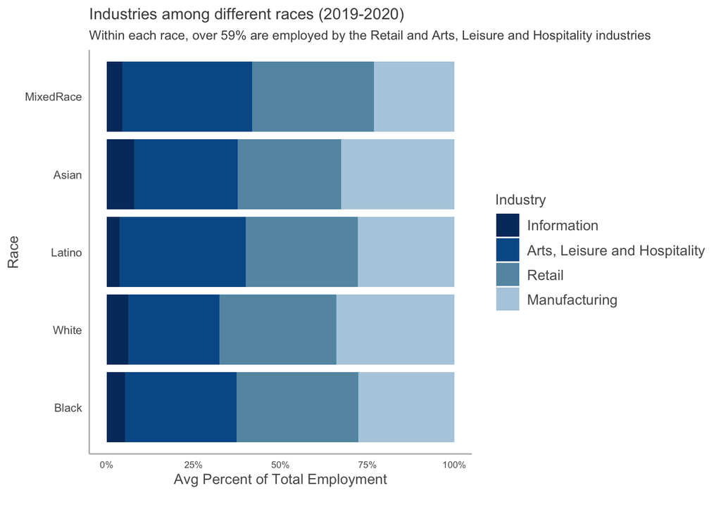

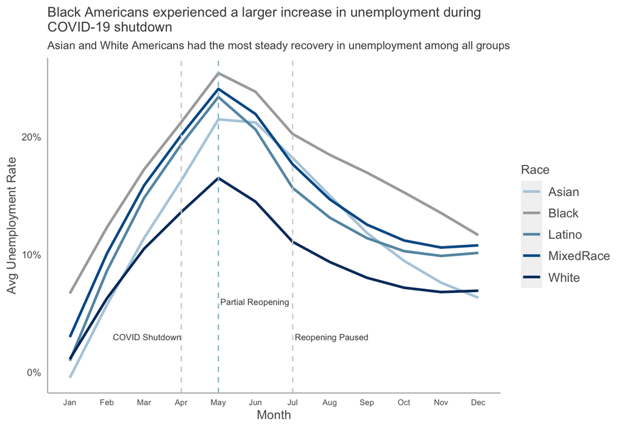

- From 2019 to 2020, the `Retail` and `Arts, Leisure and Hospitality` industries (combined) employed 72.32% of Mixed Race Americans, 68.40% of Latino Americans, and 67.10% of Black Americans.
- Black Americans experienced the most significant increase in unemployment during the COVID-19 shutdown. The spike in unemployment rates for White Americans was lower compared to other races.
- Asian and White Americans had the most steady recovery in unemployment among all groups, but unemployment recovery is slower for Black Americans.

**By Gender**

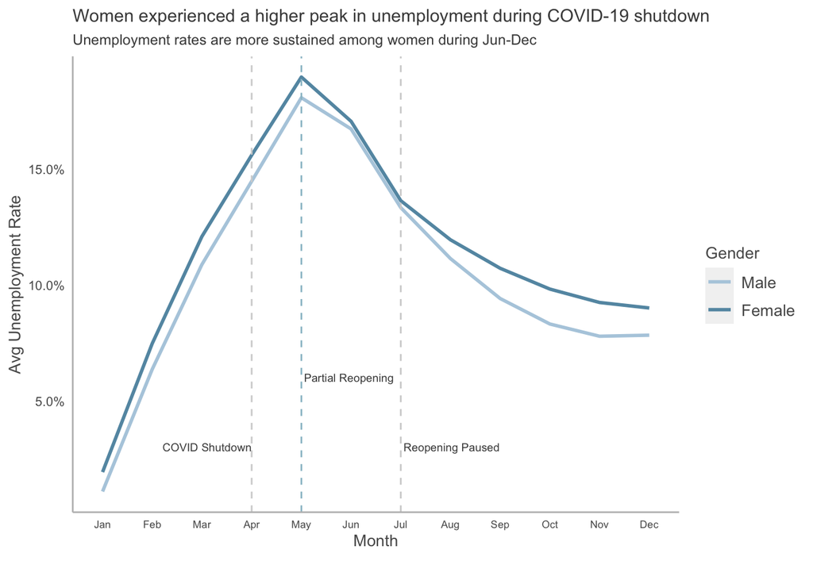

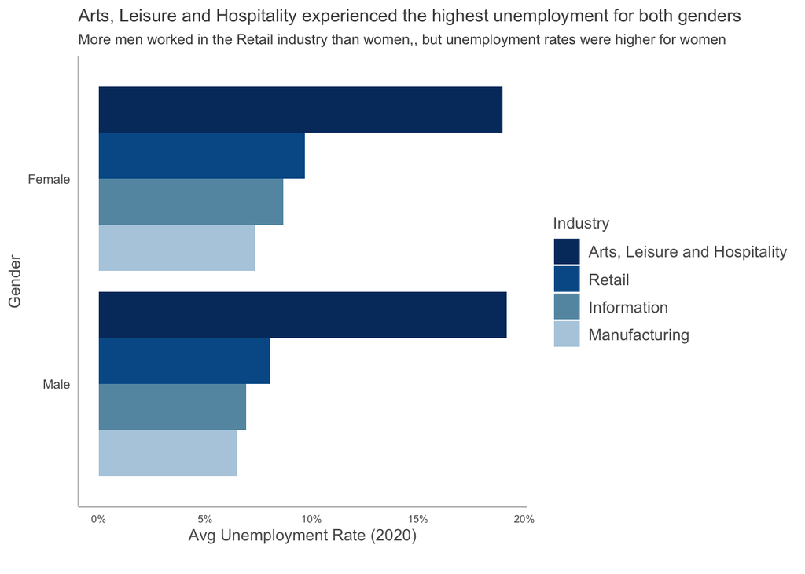